# Probability (learned from edx (Probability), note: the note part are exactly the same of edx course)

Elham Sharifin

4/10/2020

## Key points: Discrete Probability

• The probability of an event is the proportion of times the event occurs when we repeat the experiment independently under the same conditions. Pr(A)=probability of event A • An event is defined as an outcome that can occur when something happens by chance. • We can determine probabilities related to discrete variables (picking a red bead, choosing 48 Democrats and 52 Republicans from 100 likely voters) and continuous variables (height over 6 feet).

## Key points: Monte Carlo Simulations

Monte Carlo simulations model the probability of different outcomes by repeating a random process a large enough number of times that the results are similar to what would be observed if the process were repeated forever. The sample() function draws random outcomes from a set of options. The replicate() function repeats lines of code a set number of times. It is used with sample() and similar functions to run Monte Carlo simulations.

### example:

following is a simple example of how we can calculate the probability of an event by Monto Carlo simulation. In this event, the calculation of exact probability was simple; however, sometimes it is not the case.

```r
beads <- rep(c("red","blue"),times=c(2,3)) #creates a run with 2 red and 3 blue
beads
```

```
## [1] "red"  "red"  "blue" "blue" "blue"
```

```r
sample(beads,1) #it shows 1 random sample of beads
```

```
## [1] "blue"
```

```r
sample(beads,5) #it shows 5 random sample of beads (2 reds, 3 blue)
```

```
## [1] "blue" "red"  "blue" "red"  "blue"
```

```r
sample(beads,5)
```

```
## [1] "red"  "red"  "blue" "blue" "blue"
```

```r
#sample(beads,6) #error, it will not replicate
sample(beads,6,replace=TRUE) #it will replicate
```

```
## [1] "red"  "blue" "red"  "blue" "blue" "blue"
```

```r
B <- 1000 #how many time to draw one bead
events <- replicate(B,sample(beads,1)) #draw 1 beads, B times
#events  it creats 1000 random events of beads
tab <- table(events)
tab
```

```
## events
## blue  red
##  595  405
```

```r
prop.table(tab)
```

```
## events
##  blue   red
## 0.595 0.405
```

### sample function

we dont need to use replecate. because sample function has this advantage that can drew a lot of samples! By default this selection is without replacement!

```r
sample(beads,5) #we will have 2 red and 3 blues
```

```
## [1] "blue" "red"  "blue" "blue" "red"
```

```r
sample(beads,5)
```

```
## [1] "blue" "blue" "blue" "red"  "red"
```

```r
sample(beads,5)
```

```
## [1] "blue" "blue" "red"  "red"  "blue"
```

```r
#sample(beads,6) #error: because it will do it without replacement
```

```r
events <- sample(beads,B,replace=TRUE) #it gives us the distibution
prop.table(table(events)) #it gives us the proportion
```

```
## events
##  blue   red
## 0.598 0.402
```

## Setting the Random Seed

The set.seed() function: because all the generated numbers are randomely selected, they are different from every person run to another one. However, if you want to make sure the results are exactly the same, we can use this function. A popular way for picking the seed is: the year - month - day. For example, we picked 1986 on December 20, 2018: 2018 − 12 − 20 = 1986.

```r
set.seed(1986)
?set.seed
```

```
## starting httpd help server ... done
```

if you run R 3.6, you can revert to the original seed setting behavior by adding the argument sample.kind=“Rounding”. For example:

```r
set.seed(1)
set.seed(1,sample.kind="Rounding") #will make R 3.6 generate a seed as in R 3.5
```

## Using the mean Function for Probability

example:

```r
beads <- rep(c("blue","red"),times=c(3,2))
beads
```

```
## [1] "blue" "blue" "blue" "red"  "red"
```

the probability of drawing a blue bead at random:

```r
mean(beads=="blue")
```

```
## [1] 0.6
```

exaplanation: in facet it will evaluate if it is true or false tha we have blue: (true,true,false,false,false). so that mean only calculate the numbers is true: (1,1,1,0,0), the means of 1+1+1+0+0/5=0.6 and in fact, it gives the proportion of TRUE. The probabilities are directly related to the proportion of events that satisfy a requirement.

## Key points: Probability Distributions

The probability distribution for a variable describes the probability of observing each possible outcome. For discrete categorical variables, the probability distribution is defined by the proportions for each group. such as beads!

## Key points: Independence

Conditional probabilities compute the probability that an event occurs given information about dependent events. For example, the probability of drawing a second king given that the first draw is a king is (if we have 4 series cards):

Pr(Card 2 is a king∣Card 1 is a king)=3/51 # we already have taken one card, so we have 51 cards!

```r
x <- sample(beads,5)
set.seed(1,sample.kind="Rounding")
x[2:5] #now the probability of red is one
```

```
## [1] "red"  "red"  "blue" "blue"
```

If two events A and B are independent, Pr(A∣B)=Pr(A) # because their probabilities do not depend on each other

To determine the probability of multiple events occurring, we use the multiplication rule.

### Equations

The multiplication rule for independent events is: Pr(A and B and C)=Pr(A)×Pr(B)×Pr(C) This is equivalent to drawing a bead with replacement!

The multiplication rule for dependent events considers the conditional probability of both events occurring: Pr(A and B)=Pr(A)×Pr(B∣A)

We can expand the multiplication rule for dependent events to more than 2 events:

Pr(A and B and C)=Pr(A)×Pr(B∣A)×Pr(C∣A and B)

### exercise:

Suppose, we have 3 cyan, 5 magneta, and 7 yellow, we take 1 card:

```r
set.seed(1,sample.kind="Rounding")
cyan <- 3
magenta <- 5
yellow <- 7

 #peobability of choosing cyan in the first round:
p_cyan_1 <-  cyan / (cyan + magenta + yellow) #without replacement
p_cyan_1
```

```
## [1] 0.2
```

```r
#probability of not choosing cyan in the second round if the first one is selected (sampling without replacement)
p_not_cyan_without <- (magenta + yellow)/(cyan + magenta + yellow-1) #without replacement
p_not_cyan_without
```

```
## [1] 0.8571429
```

```r
#probability of not choosing cyan in the second round if the first one is selected (sampling without replacement)
p_not_cyan_with <- (magenta + yellow)/(cyan + magenta + yellow) #without replacement
p_not_cyan_with
```

```
## [1] 0.8
```

```r
#the probability that the first draw is cyan and the second draw is not cyan
p_cyan_1*p_not_cyan_without
```

```
## [1] 0.1714286
```

```r
p_cyan_1*p_not_cyan_with
```

```
## [1] 0.16
```

## Key points: Combinations and Permutations

paste() joins two strings and inserts a space in between. expand.grid() gives the combinations of 2 vectors or lists. permutations(n,r) from the gtools package lists the different ways that r items can be selected from a set of n options when order matters. combinations(n,r) from the gtools package lists the different ways that r items can be selected from a set of n options when order does not matter.

### Code: Introducing paste() and expand.grid()

```r
# joining strings with paste
number <- "Three"
suit <- "Hearts"
paste(number, suit)
```

```
## [1] "Three Hearts"
```

```r
# joining vectors element-wise with paste
paste(letters[1:5], as.character(1:5))
```

```
## [1] "a 1" "b 2" "c 3" "d 4" "e 5"
```

```r
# generating combinations of 2 vectors with expand.grid
expand.grid(pants = c("blue", "black"), shirt = c("white", "grey", "plaid"))
```

```
##   pants shirt
## 1  blue white
## 2 black white
## 3  blue  grey
## 4 black  grey
## 5  blue plaid
## 6 black plaid
```

### Code: Generating a deck of cards

```r
suits <- c("Diamonds", "Clubs", "Hearts", "Spades")
numbers <- c("Ace", "Deuce", "Three", "Four", "Five", "Six", "Seven", "Eight", "Nine", "Ten", "Jack", "Queen", "King")
deck <- expand.grid(number = numbers, suit = suits)
deck <- paste(deck$number, deck$suit)

# probability of drawing a king
kings <- paste("King", suits)
mean(deck %in% kings)
```

```
## [1] 0.07692308
```

### Code: Permutations and combinations

Correction: The code shown does not generate all 7 digit phone numbers because phone numbers can have repeated digits. It generates all possible 7 digit numbers without repeats.

```r
library(gtools)
permutations(5,2) # ways to choose 2 numbers in order from 1:5 without replacement (when we take a number, it cannot be appeared again)
```

```
##       [,1] [,2]
##  [1,]    1    2
##  [2,]    1    3
##  [3,]    1    4
##  [4,]    1    5
##  [5,]    2    1
##  [6,]    2    3
##  [7,]    2    4
##  [8,]    2    5
##  [9,]    3    1
## [10,]    3    2
## [11,]    3    4
## [12,]    3    5
## [13,]    4    1
## [14,]    4    2
## [15,]    4    3
## [16,]    4    5
## [17,]    5    1
## [18,]    5    2
## [19,]    5    3
## [20,]    5    4
```

```r
all_phone_numbers <- permutations(10, 7, v = 0:9) #v=0:9 sjows the vector. for example it cannot be from 1:10
n <- nrow(all_phone_numbers)
index <- sample(n, 5) #it show 5 random number
all_phone_numbers[index,]  #it shows the phone number associated with the index
```

```
##      [,1] [,2] [,3] [,4] [,5] [,6] [,7]
## [1,]    2    6    9    1    0    8    7
## [2,]    3    7    4    9    5    0    1
## [3,]    5    7    4    3    1    0    2
## [4,]    9    0    6    8    3    1    4
## [5,]    2    0    3    4    6    9    1
```

```r
permutations(3,2)    # order matters
```

```
##      [,1] [,2]
## [1,]    1    2
## [2,]    1    3
## [3,]    2    1
## [4,]    2    3
## [5,]    3    1
## [6,]    3    2
```

```r
combinations(3,2)    # order does not matter
```

```
##      [,1] [,2]
## [1,]    1    2
## [2,]    1    3
## [3,]    2    3
```

### Code: Probability of drawing a second king given that one king is drawn

```r
suits <- c("Diamonds", "Clubs", "Hearts", "Spades")
numbers <- c("Ace", "Deuce", "Three", "Four", "Five", "Six", "Seven", "Eight", "Nine", "Ten", "Jack", "Queen", "King")
deck <- expand.grid(number = numbers, suit = suits)
deck <- paste(deck$number, deck$suit)

# probability of drawing a king
kings <- paste("King", suits)
mean(deck %in% kings)
```

```
## [1] 0.07692308
```

```r
# Probability of drawing a second king given that one king is drawn
hands <- permutations(52,2, v = deck) #select from vectors that are card names (deck)
first_card <- hands[,1] #it shows the column 1
second_card <- hands[,2] #column 2 of hands
sum(first_card %in% kings)
```

```
## [1] 204
```

```r
sum(first_card %in% kings & second_card %in% kings) / sum(first_card %in% kings)
```

```
## [1] 0.05882353
```

```r
# it is equivalant with Pr(B|A)=Pr(A and B)/Pr(A) #conditional probability for dependent variables!!!
```

### Code: Probability of a natural 21 in blackjack natural 21: (natural 21: Ace+king,queen,jack,ten)

```r
suits <- c("Diamonds", "Clubs", "Hearts", "Spades")
numbers <- c("Ace", "Deuce", "Three", "Four", "Five", "Six", "Seven", "Eight", "Nine", "Ten", "Jack", "Queen", "King")
deck <- expand.grid(number = numbers, suit = suits)
deck <- paste(deck$number, deck$suit)

aces <- paste("Ace",suits) #the vector include all Aces
facecard <- c("King","Queen","Jack","Ten")
facecard <- expand.grid(number=facecard,suit=suits)
facecard <- paste(facecard$number,facecard$suit) #the vector includes all facecard

hands <- combinations(52,2,v=deck) #all combination of picking 2 cards from 4 hands (13*4=52)

#probability of a natural 21 given that the ace is listed first in  'combinations'
mean(hands[,1] %in% aces & hands[,2] %in% facecard)
```

```
## [1] 0.04826546
```

```r
# for more caustion: probability of a natural 21 checking for both ace first and ace second (it means: first aces and second facecard or first facecard and second aces)
mean((hands[,1] %in% aces & hands[,2] %in% facecard)|(hands[,2] %in% aces & hands[,1] %in% facecard))
```

```
## [1] 0.04826546
```

### Code: Monte Carlo simulation of natural 21 in blackjack

```r
# instead of finding the exact combination as previouse, we can use Monto Carlo and find the approximate probability
set.seed(1986)
suits <- c("Diamonds", "Clubs", "Hearts", "Spades")
numbers <- c("Ace", "Deuce", "Three", "Four", "Five", "Six", "Seven", "Eight", "Nine", "Ten", "Jack", "Queen", "King")
deck <- expand.grid(number = numbers, suit = suits)
deck <- paste(deck$number, deck$suit)

aces <- paste("Ace",suits)

facecard <- c("King","Queen","Jack","Ten")
facecard <- expand.grid(number=facecard,suit=suits)
facecard <- paste(facecard$number,facecard$suit)

hands <- sample(deck,2)  #drawing two card without replacement
hands
```

```
## [1] "King Clubs"    "Jack Diamonds"
```

```r
# code for B=10,000 hands of blackjack
B <- 10000
results <- replicate(B,{
  hands <- sample(deck,2)
  (hands[1] %in% aces & hands[2] %in% facecard)|(hands[2] %in% aces & hands[1] %in% facecard)
})
mean(results)
```

```
## [1] 0.0492
```

## Key points: The Birthday Problem

duplicated() takes a vector and returns a vector of the same length with TRUE for any elements that have appeared previously in that vector. We can compute the probability of shared birthdays in a group of people by modeling birthdays as random draws from the numbers 1 through 365. We can then use this sampling model of birthdays to run a Monte Carlo simulation to estimate the probability of shared birthdays.

### Code: The birthday problem

what is the chance that at least two people in a classromm of 50 peopel has the same birthday?

```r
# how many duplicate birthday in a group of 50
n <- 50
bdays <- sample(1:365,n,replace = TRUE)
any(duplicated(bdays))  #it is only for one sample
```

```
## [1] TRUE
```

```r
# Monte Carlo simulation with B=10000 replicates
# for finding the probability, we have to run it for many times and have a lot of sampels
B <- 10000
results <- replicate(B,{   # returns vector of B logical values
  bdays <- sample(1:365,n,replace=TRUE)
  any(duplicated(bdays))
})
mean(results)  #calculate the proportion or probability of duplicated birthdays
```

```
## [1] 0.9706
```

## Key points: sapply

Some functions automatically apply element-wise to vectors, such as sqrt() and *. However, other functions do not operate element-wise by default. This includes functions we define ourselves.

The function sapply(x, f) allows any other function f to be applied element-wise to the vector x.

The probability of an event happening is 1 minus the probability of that event not happening: Pr(event)=1−Pr(no event)

We can compute the probability of shared birthdays mathematically: Pr(shared birthdays)=1−Pr(no shared birthdays)=1−(1×364/365×364/365× …× (365-n+1)/365)

```r
# function of calculation of probability of same birth days across n people
compute_bday <- function(n,B=10000){
  same_day <- replicate(B,{
    bday <- sample(1:365,n,replace = TRUE)
    any(duplicated(bday))
  })
  mean(same_day)
}

n <- seq(1,60)
```

### Code: Element-wise operation over vectors and sapply:

```r
x <- 1:10
sqrt(x) #sqrt applys on every elements of the vector x
```

```
##  [1] 1.000000 1.414214 1.732051 2.000000 2.236068 2.449490 2.645751 2.828427
##  [9] 3.000000 3.162278
```

```r
y <- 1:10
x*y  #it multiply each elements from x on y
```

```
##  [1]   1   4   9  16  25  36  49  64  81 100
```

```r
compute_bday(n)    # does not iterate over the vector n without sapply
```

```
## [1] 0
```

```r
x <- 1:10
sapply(x,sqrt) #this is equivalent with sqrt(x)
```

```
##  [1] 1.000000 1.414214 1.732051 2.000000 2.236068 2.449490 2.645751 2.828427
##  [9] 3.000000 3.162278
```

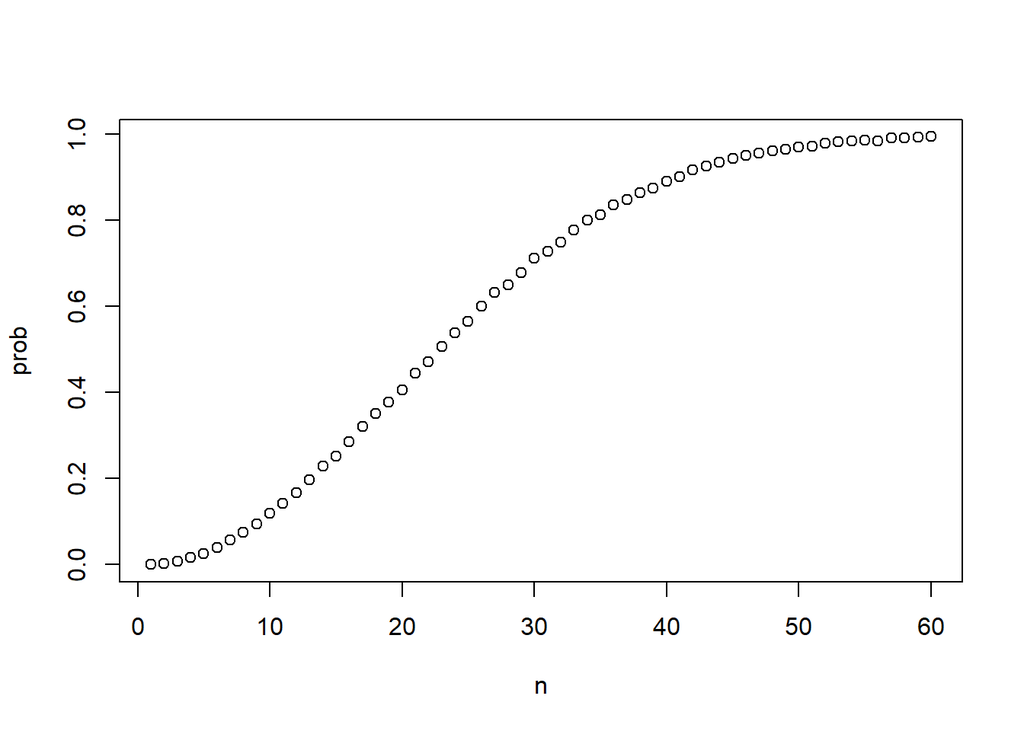

```r
prob <- sapply(n,compute_bday) #element-wise application of compute_prob to n 9insteaf of reiting a loop, in R we prefer to use sapply)

plot(n,prob)  #n the size of the group
```

#### Code: Computing birthday problem probabilities with sapply if we calculate the probability of peoples do not have the same birthday: Pr(person 1 has unique bday) = 1 Pr(person 2 has a uique birthday|person 1 has a unique bday) = 364/365 Pr(person 3 has a unique bday | person 1 , 2 have unique bdays)=363/365 … (365/365)*(364/365)*(363/365)*…*((365-(n-1))/365) now we can write a function for that.

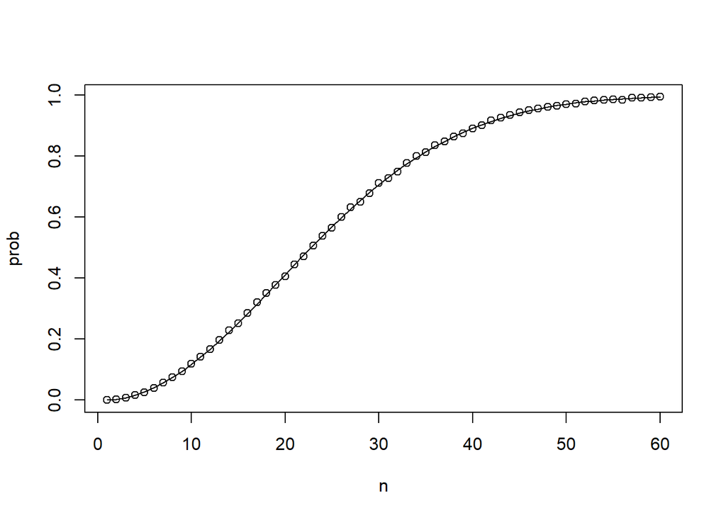

```r
# exact formulation for bday problem
exact_prob <- function(n){
  prob_unique <- seq(365,365-n+1)/365
  1 - prod(prob_unique)
}

# applying function element-wise to vector of n values
eprob <- sapply(n, exact_prob)

# plotting Monte Carlo results and exact probabilities on same graph
plot(n, prob)    # plot Monte Carlo results
lines(n, eprob)   # add line for exact prob
```

```r
# as seen, monto-carlo simulation can predict the probability very good.
```

## Key points: How Many Monte Carlo Experiments are Enough?

The larger the number of Monte Carlo replicates B, the more accurate the estimate.

Determining the appropriate size for B can require advanced statistics.

One practical approach is to try many sizes for B and look for sizes that provide stable estimates.

The following code runs Monte Carlo simulations to estimate the probability of shared birthdays using several B values and plots the results. When B is large enough that the estimated probability stays stable, then we have selected a useful value of B.

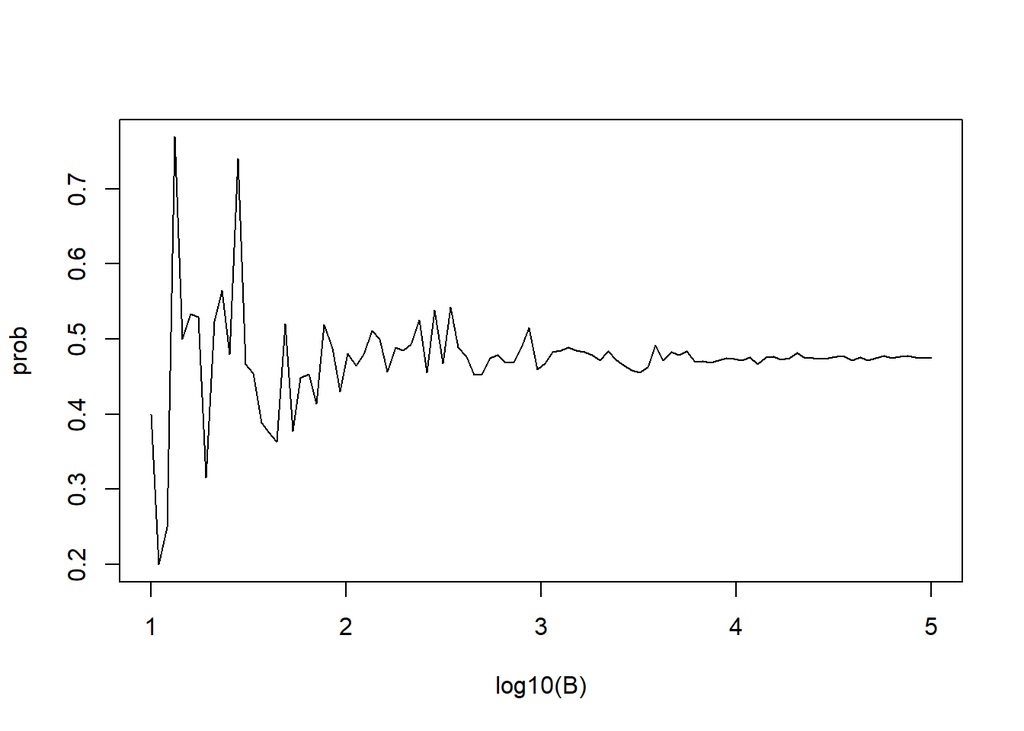

```r
# Code: Estimating a practical value of B
B <- 10^seq(1,5,length=100)

compute_bday <- function(B,n=22){
  same_day <- replicate(B,{
    bday <- sample(1:365,n,replace = TRUE)
    any(duplicated(bday))
  })
  mean(same_day)
}

prob <- sapply(B, compute_bday) # apply compute_bday to many values of B
plot(log10(B), prob, type = "l")    # plot a line graph of estimates
```

### Exercise (independent) suppose we have a box cotaining 3 cyan, 5 magenta, and 7 yellow balls. suppose we draw 5 balls with replacement, and all have been yellow. what is the probability that the sixth draw become yellow too?

```r
# Sampling with replacement
yellow <- 7
magenta <- 5
cyan <-3

prob_yellow <- yellow/(yellow+magenta+cyan)

prob_7_yellow <- prob_yellow #The probability of drawing a yellow ball is not dependent of previous draws when balls are replaced after each draw. If two events A and B are independent,Pr(A∣B)=Pr(A)

prob_7_yellow
```

```
## [1] 0.4666667
```

### Exercise (Rolling a die)

suppose we have a die with six sides: what is the probability of not-seeing a six in one roll? what is the probability of not-seeing a six for all of the six rolls?

```r
prob_no6 <- 5/6
prob_no6_6roll <- prob_no6*prob_no6*prob_no6*prob_no6*prob_no6*prob_no6
prob_no6_6roll
```

```
## [1] 0.334898
```

### Exercise (winning between two teams)

Suppose there are two teams Esteghlas and Piroozi and Esteghlala is more stronger and has 1 60% of wininng in front of piroozi. what is the probability that piroozi win at least one game? (Remember that the piroozi must win one of the first four games, or the series will be over!)

```r
# at least win 1 game = 1-(pirrozi win 0 game)
#pirrozi win 0 game = esteghala winn all of 4 games
win_esteghlal_4 <- 0.6*0.6*0.6*0.6
win_pirrozi_1 <- 1- win_esteghlal_4
win_pirrozi_1
```

```
## [1] 0.8704
```

###Exercise: Monte Carlo simulation for Esteghlal winning a game: Create a Monte Carlo simulation to confirm your answer to the previous problem by estimating how frequently the Celtics win at least 1 of 4 games (assume: B <- 10000).

```r
simulated_games <- sample (c("win","lose"),4,replace = TRUE, prob = c(0.4,0.6)) #these are simulated games for piroozi that the probabilities are not equal
simulated_games
```

```
## [1] "win"  "lose" "lose" "lose"
```

```r
B <- 10000
perspolis_win <- replicate(B,{
  simulated_games <- sample (c("win","lose"),4,replace = TRUE, prob = c(0.4,0.6))
  any(simulated_games==c("win"))
})
mean(perspolis_win)
```

```
## [1] 0.8729
```

## Key points: The Addition Rule

The addition rule states that the probability of event A or event B happening is the probability of event A plus the probability of event B minus the probability of both events A and B happening together. Pr(A or B)=Pr(A)+Pr(B)−Pr(A and B) Note that (A or B) is equivalent to (A|B)

### example:

Example: The addition rule for a natural 21 in blackjack. We apply the addition rule where A = drawing an ace then a facecard and B = drawing a facecard then an ace. Note that in this case, both events A and B cannot happen at the same time, so Pr(A and B)=0. Pr(ace_then_facecard) = (4/52)*(16/51) Pr(facecard_then_ace) = (16/51)*(4/52) Pr(ace_then_facecard | facecard_then_ace)= (4/52) * (16/51) + (16/51) *(4/52)

## Key points: The Monty Hall Problem

Monte Carlo simulations can be used to simulate random outcomes, which makes them useful when exploring ambiguous or less intuitive problems like the Monty Hall problem.

In the Monty Hall problem, contestants choose one of three doors that may contain a prize. Then, one of the doors that was not chosen by the contestant and does not contain a prize is revealed. The contestant can then choose whether to stick with the original choice or switch to the remaining unopened door.

Although it may seem intuitively like the contestant has a 1 in 2 chance of winning regardless of whether they stick or switch, Monte Carlo simulations demonstrate that the actual probability of winning is 1 in 3 with the stick strategy and 2 in 3 with the switch strategy.

### Code: Monte Carlo simulation of stick strategy

```r
doors <- as.character(1:3)
doors
```

```
## [1] "1" "2" "3"
```

```r
prize <- sample(c("car","goat","goat")) # puts prizes in random order
prize
```

```
## [1] "goat" "car"  "goat"
```

```r
prize_door <- doors[prize=="car"] # note which door has prize
prize_door
```

```
## [1] "2"
```

```r
my_pick <- sample(doors,1) # note which door is chosen
my_pick
```

```
## [1] "3"
```

```r
show <- sample(doors[!doors %in% c(my_pick,prize_door)],1) # open door with no prize that isn't chosen
show
```

```
## [1] "1"
```

```r
stick <- my_pick
stick == prize_door
```

```
## [1] FALSE
```

```r
#Monto_carlo simulation
B <- 10000
stick <- replicate(B, {
    doors <- as.character(1:3)
    prize <- sample(c("car","goat","goat"))    # puts prizes in random order
    prize_door <- doors[prize == "car"]    # note which door has prize
    my_pick  <- sample(doors, 1)    # note which door is chosen
    show <- sample(doors[!doors %in% c(my_pick, prize_door)],1)    # open door with no prize that isn't chosen
    stick <- my_pick    # stick with original door
    stick == prize_door    # test whether the original door has the prize
})
mean(stick)    # probability of choosing prize door when sticking
```

```
## [1] 0.3316
```

### Code: Monte Carlo simulation of switch strategy

```r
doors <- as.character(1:3)
doors
```

```
## [1] "1" "2" "3"
```

```r
prize <- sample(c("car","goat","goat")) # puts prizes in random order
prize
```

```
## [1] "car"  "goat" "goat"
```

```r
prize_door <- doors[prize=="car"] # note which door has prize
prize_door
```

```
## [1] "1"
```

```r
my_pick <- sample(doors,1) # note which door is chosen
my_pick
```

```
## [1] "2"
```

```r
show <- sample(doors[!doors %in% c(my_pick,prize_door)],1) # open door with no prize that isn't chosen
show
```

```
## [1] "3"
```

```r
switch <- doors[!doors%in%c(my_pick,show)]  ## switch to the door that wasn't chosen first or opened
switch
```

```
## [1] "1"
```

```r
switch == prize_door
```

```
## [1] TRUE
```

```r
# Monto_carlo simulation
B <- 10000
switch <- replicate(B, {
    doors <- as.character(1:3)
    prize <- sample(c("car","goat","goat"))    # puts prizes in random order
    prize_door <- doors[prize == "car"]    # note which door has prize
    my_pick  <- sample(doors, 1)    # note which door is chosen first
    show <- sample(doors[!doors %in% c(my_pick, prize_door)], 1)    # open door with no prize that isn't chosen
    switch <- doors[!doors%in%c(my_pick, show)]    # switch to the door that wasn't chosen first or opened
    switch == prize_door    # test whether the switched door has the prize
})
mean(switch)    # probability of choosing prize door when switching
```

```
## [1] 0.6601
```

### Exercise: The Cavs and the Warriors

Two teams of Cavs and the Warriors are playing a seven game championship series. The first to win four games wins the series. The teams are equally good, so they each have a 50-50 chance of winning each game. If the Cavs lose the first game, what is the probability that they win the series.

```r
## Monto Carlo simulation
simulated_games <- sample (c("win","lose"),6,replace = TRUE, prob = c(0.5,0.5))
simulated_games
```

```
## [1] "lose" "win"  "lose" "win"  "lose" "lose"
```

```r
B <- 10000
set.seed(1) #if we want that our answer become identical with edx
Warriors_win <- replicate(B,{
  simulated_games <- sample (c("win","lose"),6,replace = TRUE, prob = c(0.5,0.5))
  })
win <- colSums(Warriors_win=="win")>=4
mean(win)
```

```
## [1] 0.3453
```

```r
#if we define win and lose as (0,1)
#sum(simulated_games)>=4  inside the Monoto caerlo before })
```

Another method:

```r
# Assign a variable 'n' as the number of remaining games.
n <- 6
n
```

```
## [1] 6
```

```r
# Assign a variable `outcomes` as a vector of possible game outcomes, where 0 indicates a loss and 1 indicates a win for the Cavs.
outcomes <- c(0:1)
outcomes
```

```
## [1] 0 1
```

```r
# Assign a variable `l` to a list of all possible outcomes in all remaining games. Use the `rep` function on `list(outcomes)` to create list of length `n`.
l <- rep(list(outcomes),n)
l
```

```
## [[1]]
## [1] 0 1
##
## [[2]]
## [1] 0 1
##
## [[3]]
## [1] 0 1
##
## [[4]]
## [1] 0 1
##
## [[5]]
## [1] 0 1
##
## [[6]]
## [1] 0 1
```

```r
# Create a data frame named 'possibilities' that contains all combinations of possible outcomes for the remaining games.
possibilities <- expand.grid(l)
possibilities
```

```
##    Var1 Var2 Var3 Var4 Var5 Var6
## 1     0    0    0    0    0    0
## 2     1    0    0    0    0    0
## 3     0    1    0    0    0    0
## 4     1    1    0    0    0    0
## 5     0    0    1    0    0    0
## 6     1    0    1    0    0    0
## 7     0    1    1    0    0    0
## 8     1    1    1    0    0    0
## 9     0    0    0    1    0    0
## 10    1    0    0    1    0    0
## 11    0    1    0    1    0    0
## 12    1    1    0    1    0    0
## 13    0    0    1    1    0    0
## 14    1    0    1    1    0    0
```

[output cut: 50 more lines]

```r
# Create a vector named 'results' that indicates whether each row in the data frame 'possibilities' contains enough wins for the Cavs to win the series.

results <- rowSums(possibilities==1)>=4
results
```

```
##  [1] FALSE FALSE FALSE FALSE FALSE FALSE FALSE FALSE FALSE FALSE FALSE FALSE
## [13] FALSE FALSE FALSE  TRUE FALSE FALSE FALSE FALSE FALSE FALSE FALSE  TRUE
## [25] FALSE FALSE FALSE  TRUE FALSE  TRUE  TRUE  TRUE FALSE FALSE FALSE FALSE
## [37] FALSE FALSE FALSE  TRUE FALSE FALSE FALSE  TRUE FALSE  TRUE  TRUE  TRUE
## [49] FALSE FALSE FALSE  TRUE FALSE  TRUE  TRUE  TRUE FALSE  TRUE  TRUE  TRUE
## [61]  TRUE  TRUE  TRUE  TRUE
```

```r
# Calculate the proportion of 'results' in which the Cavs win the series. Print the outcome to the console.
mean(results)
```

```
## [1] 0.34375
```

### Exercise:

Suppose two teams of A, and B are playing a sevn-series game. Team A is better than B and has a p>0.5chance of winning each game.compute the probability of wininng for the p <- seq(0.5,0.95,0.025)

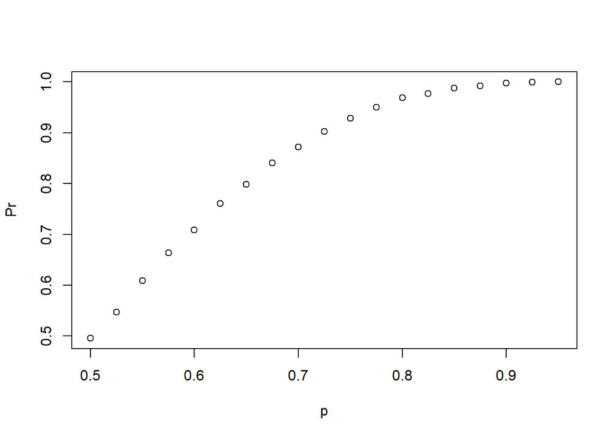

```r
p <- seq(0.5,0.95,0.025)  #probability that team A wins
## Given a value 'p', the probability of winning the series for the underdog team B can be computed with the following function based on a Monte Carlo simulation:
prob_win <- function(p){
  results <- replicate(B,{
    b_win <- sample(c(0,1),7,replace = TRUE, prob=c(1-p,p)) #1-p:0 losing #p:1 wining
    sum(b_win) >= 4
  })
  mean(results)
}
Pr <- sapply(p,prob_win) ## Apply the 'prob_win' function across the vector of probabilities that team A will win to determine the probability that team B will win. Call this object 'Pr'.
plot(p,Pr)
```

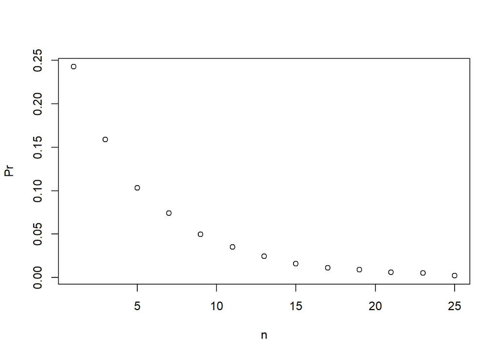

```r
B <- 10000
compute_win <- function(n,p=0.75){
  results <- replicate(B,{
    b_win <- sample(c(1,0),n,replace=TRUE,prob=c(1-p,p))
    sum(b_win)>=(n+1)/2
  })
  mean(results)
}

n <- seq(1,25,2)
Pr <- sapply(n,compute_win)
plot(n,Pr)
```

## Assessment:Olympic Running in the final of 200m, theer are 8 people who fight for the three medals in which order is matter. in Olympic 2012, three of eight runner were from Jamaica and other fiver runners from other countries. all of three medal were won by Jamaica .

```r
library(gtools)
library(tidyverse)
# different ways the three medals can be distributed accross runners:
medals <- permutations(8,3)
nrow(medals)
```

```
## [1] 336
```

```r
# different ways that three medals can be distributed among three Jamaican runners:
Jamaica_medals <- permutations(3,3)
nrow(Jamaica_medals )
```

```
## [1] 6
```

```r
# probability that all three medals are won by Jamaica n runners:
Pr_Jamaica  <- nrow(Jamaica_medals)/nrow(medals)
Pr_Jamaica
```

```
## [1] 0.01785714
```

```r
# Monto carlo
runners <- c("Jamaica", "Jamaica", "Jamaica", "USA", "Ecuador", "Netherlands", "France", "South Africa")
B <- 10000
set.seed(1)
jam_win <- replicate(B,{
  simulated_games <- sample(runners,3) #be careful: replace=false order is matter
  all(simulated_games=="Jamaica")
   })
mean(jam_win)
```

```
## [1] 0.0165
```